# Sommaire (esilv_tp_1_python_listes_prediction_auteur_classes)

### 1) les listes

1.1) longueur de liste  
1.2) sous ensemble  
1.3) slicing  
1.2) attention : itérateurs  
1.3) enchaînement des sliceurs  
1.4) méthodes des listes  
1. 4.1) extend / append  
1.5) Chaînes de caractères  
1.6) Durée d'insertion en queue / tête de liste  
1. 6.1) fonction de mesure de temps de calcul  
1. 6.2) temps d'insertion en queue de liste  
1. 6.3) temps d'insertion en tête de liste  
1. 6.4) La classe "dequeue"

### 2) comprehension list

2.1) construction 'classique' de liste dans une boucle for  
2.2) construction 'moderne' de liste via une comprehension list  
2.3) comprehension list conditionelle : condition simple => le if est à la fin  
2.4) comprehension list conditionelle : condition complète => le if est au milieu

### 3) functions

### 4) lambda functions

### 5) map et filter

5.1) map permet d'appliquer une fonction sur chaque élément d'une liste  
5.2) filter : permet de filtrer une liste sur une condition (renvoie la sous liste qui passe la condition)  
5.3) enumerate

### 6) les dictionnaires : avec des accolades

6.1) itérer sur un dico  
6.2) Import de nltk : Natural Language ToolKit  
6.3) comptage "natif" du nombre d'occurence des mots  
6.4) utilisation de "defaultdict"  
6.5) tri des mots par nombre d'occurence

### 7) amusons nous

7.1) rassembler les auteurs avec leurs oeuvres  
7.2) concaténer les textes pour chaque auteur  
7.3) recherchons l'auteur probable d'un texte

### 8) classes

8.1) héritage de classes

```python
print("Hello world !")
```

```
Hello world !
```

# Manipulation de jupyter :

## Sortie de cellule = ESC

- ajouter une cellule en dessous : B
- ajouter une cellule au dessus : A
- Supprimer une cellule : DD
- Transformer une cellule en MarkDown : M

## Entrée de cellule = Enter

- Exécuter du code : ALT + ENTER => exécute et active la cellule du dessous
- Exécuter du code : CTRL + ENTER => exécute la cellule et reste dedans

Appel de commandes systèmes avec le point d'exclamation

```python
!git remote -v
```

```
'git' n’est pas reconnu en tant que commande interne
ou externe, un programme exécutable ou un fichier de commandes.
```

```python
!git add 20190906_td_python_IBO3.ipynb
!git commit -m "fin"
!git push origin master
```

```
'git' n’est pas reconnu en tant que commande interne
ou externe, un programme exécutable ou un fichier de commandes.
'git' n’est pas reconnu en tant que commande interne
ou externe, un programme exécutable ou un fichier de commandes.
'git' n’est pas reconnu en tant que commande interne
ou externe, un programme exécutable ou un fichier de commandes.
```

# 1) les listes

```python
une_liste = [1,2,3,4,5, "a", "b", "c", ["une autre liste"]]
une_liste
```

```
[1, 2, 3, 4, 5, 'a', 'b', 'c', ['une autre liste']]
```

## 1.1) longueur de liste

```python
len(une_liste)
```

```
9
```

## 1.2) sous ensemble

```python
indice_position = 1
une_liste[indice_position]
```

```
2
```

## 1.3) slicing

```python
# éléments 1 à 4 (le 5 est pas inclu)
une_liste[1:5]
```

```
[2, 3, 4, 5]
```

```python
# dernier élément : -1
une_liste[-1]
```

```
['une autre liste']
```

```python
# les trois derniers éléments : "-3:"
une_liste[-3:]
```

```
['b', 'c', ['une autre liste']]
```

```python
# un élément sur 2
une_liste[::2]
```

```
[1, 3, 5, 'b', ['une autre liste']]
```

```python
pas = 2
une_liste[::pas]
```

```
[1, 3, 5, 'b', ['une autre liste']]
```

## 1.2) attention : itérateurs

```python
un_dix = list(range(10))
```

```python
un_dix[::2]
```

```
[0, 2, 4, 6, 8]
```

```python
un_dix[3::2] # un élément sur deux à partir du 3ème
```

```
[3, 5, 7, 9]
```

```python
un_cent = list(range(100))
```

## 1.3) enchaînement des sliceurs

```python
un_cent[-40::-2][:5]
# les 5 premiers éléments de la liste des éléments de 60 à 0
# avec un pas de 2
```

```
[60, 58, 56, 54, 52]
```

## 1.4) méthodes des listes

- Autocomplétion : TAB après le point sur les objets

```python
un_cent.pop() # pop : extrait et retourne le dernier élément de la liste
```

```
99
```

- documentation de méthode : mettre les parenthèses, puis faire Maj + Tab

```python
un_cent.reverse()
```

```python
un_cent
```

```
[98,
 97,
 96,
 95,
 94,
 93,
 92,
 91,
 90,
 89,
 88,
 87,
 86,
 85,
 84,
 83,
 82,
 81,
 80,
 79,
 78,
 77,
 76,
 75,
 74,
 73,
 72,
 71,
 70,
 69,
 68,
 67,
 66,
 65,
 64,
 63,
 62,
 61,
 60,
 59,
```

[output cut: 44 more lines]

```
 14,
 13,
 12,
 11,
 10,
 9,
 8,
 7,
 6,
 5,
 4,
 3,
 2,
 1,
 0]
```

```python
len(un_cent)
```

```
99
```

## 1.4.1) extend / append

```python
un_cent.extend(un_cent)
```

```python
len(un_cent)
```

```
198
```

```python
un_cent
```

```
[98,
 97,
 96,
 95,
 94,
 93,
 92,
 91,
 90,
 89,
 88,
 87,
 86,
 85,
 84,
 83,
 82,
 81,
 80,
 79,
 78,
 77,
 76,
 75,
 74,
 73,
 72,
 71,
 70,
 69,
 68,
 67,
 66,
 65,
 64,
 63,
 62,
 61,
 60,
 59,
```

[output cut: 143 more lines]

```
 14,
 13,
 12,
 11,
 10,
 9,
 8,
 7,
 6,
 5,
 4,
 3,
 2,
 1,
 0]
```

```python
un_cent.append(3)
```

```python
len(un_cent)
```

```
199
```

- Append : ajoute un élément

```python
un_cent.append([3, 2, 3, 3, 4])
len(un_cent)
```

```
200
```

```python
un_cent
```

```
[98,
 97,
 96,
 95,
 94,
 93,
 92,
 91,
 90,
 89,
 88,
 87,
 86,
 85,
 84,
 83,
 82,
 81,
 80,
 79,
 78,
 77,
 76,
 75,
 74,
 73,
 72,
 71,
 70,
 69,
 68,
 67,
 66,
 65,
 64,
 63,
 62,
 61,
 60,
 59,
```

[output cut: 145 more lines]

```
 12,
 11,
 10,
 9,
 8,
 7,
 6,
 5,
 4,
 3,
 2,
 1,
 0,
 3,
 [3, 2, 3, 3, 4]]
```

- Extend : fusionne des listes

```python
un_cent.extend([5553, 2, 3, 3, 4,666])
len(un_cent) #rajoute 6
```

```
206
```

```python
un_cent
```

```
[98,
 97,
 96,
 95,
 94,
 93,
 92,
 91,
 90,
 89,
 88,
 87,
 86,
 85,
 84,
 83,
 82,
 81,
 80,
 79,
 78,
 77,
 76,
 75,
 74,
 73,
 72,
 71,
 70,
 69,
 68,
 67,
 66,
 65,
 64,
 63,
 62,
 61,
 60,
 59,
```

[output cut: 151 more lines]

```
 6,
 5,
 4,
 3,
 2,
 1,
 0,
 3,
 [3, 2, 3, 3, 4],
 5553,
 2,
 3,
 3,
 4,
 666]
```

- count : compte le nombre d'occurence d'une valeur dans la liste

```python
valeur_cherchee  = 10
un_cent.count(valeur_cherchee)
```

```
2
```

## 1.5) Chaînes de caractères

```python
une_chaine_de_caractere = "dsfghjklmsdfghjkldfghjklfdghjkl"
une_chaine_de_caractere
```

```
'dsfghjklmsdfghjkldfghjklfdghjkl'
```

```python
une_chaine_de_caractere[:3]
```

```
'dsf'
```

```python
debut = 5
fin = 10
for caractere in une_chaine_de_caractere[debut:fin+1]:
    print(caractere)
```

```
j
k
l
m
s
d
```

# 1.6) Durée d'insertion en queue / tête de liste

## 1.6.1) fonction de mesure de temps de calcul

```python
import time
import pandas as pd
```

```python
def duree(debut):
    return time.time() - debut
```

## 1.6.2) temps d'insertion en queue de liste

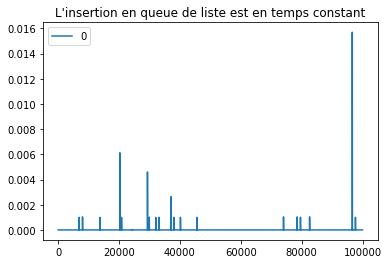

```python
conclusion = u"L'insertion en queue de liste est en temps constant"
liste      = list()
durees     = {}
for i in range(100000):
    debut = time.time()
    liste.append(i)
    fin   = time.time()
    durees[i] = fin - debut

df = pd.DataFrame.from_dict(durees, orient='index')
df.plot(title=conclusion)
```

## 1.6.3) temps d'insertion en tête de liste

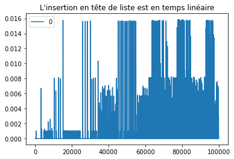

```python
conclusion         = u"L'insertion en tête de liste est en temps linéaire"
liste              = list()
position_insertion = 0
durees             = {}
for i in range(100000):
    debut = time.time()
    liste.insert(position_insertion, i)
    fin = time.time()
    durees[i] = fin - debut

df = pd.DataFrame.from_dict(durees, orient='index')
df.plot(title=conclusion)
```

## 1.6.4) La classe "dequeue"

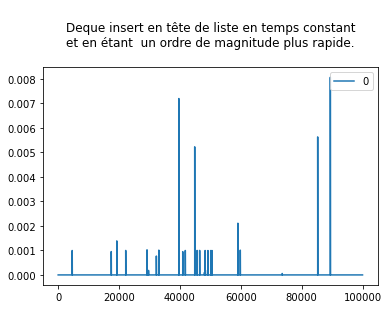

```python
from collections import deque
conclusion         = u"""
Deque insert en tête de liste en temps constant
et en étant  un ordre de magnitude plus rapide.
"""
double_queue       = deque()
position_insertion = 0
durees             = {}
for i in range(100000):
    debut = time.time()
    double_queue.appendleft(i)
    fin = time.time()
    durees[i] = fin - debut

df = pd.DataFrame.from_dict(durees, orient='index')
df.plot(title=conclusion)
```

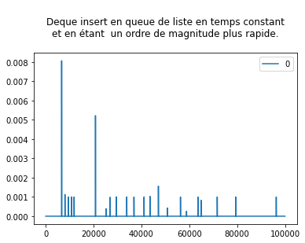

```python
from collections import deque
conclusion         = u"""
Deque insert en queue de liste en temps constant
et en étant  un ordre de magnitude plus rapide.
"""
double_queue       = deque()
position_insertion = 0
durees             = {}
for i in range(100000):
    debut = time.time()
    double_queue.append(i)
    fin = time.time()
    durees[i] = fin - debut

df = pd.DataFrame.from_dict(durees, orient='index')
df.plot(title=conclusion)
```

# 2) comprehension list

```python
import random
n     = 10
```

### 2.1) construction 'classique' de liste dans une boucle for

```python
liste = []
for _ in range(n):
    caractere = random.choice(une_chaine_de_caractere)
    liste.append(caractere)
```

```python
liste
```

```
['k', 'j', 'h', 'h', 'l', 's', 'l', 'j', 'm', 'd']
```

### 2.2) construction 'moderne' de liste via une comprehension list

```python
liste2 = [random.choice(une_chaine_de_caractere) for _ in range(n)]
liste2
```

```
['d', 'f', 'f', 'f', 'f', 'h', 'l', 'd', 'f', 'l']
```

```python
liste2 = ["e" for _ in range(n)]
liste2
```

```
['e', 'e', 'e', 'e', 'e', 'e', 'e', 'e', 'e', 'e']
```

## multiplication de listes

```python
liste2 = ["e"] * 10
liste2
```

```
['e', 'e', 'e', 'e', 'e', 'e', 'e', 'e', 'e', 'e']
```

## 2.3) comprehension list conditionelle : condition simple => le if est à la fin

```python
liste2 = [ _ for _ in range(n) if _%2==0]
liste2
```

```
[0, 2, 4, 6, 8]
```

## 2.4) comprehension list conditionelle : condition complète => le if est au milieu

```python
liste2 = [ _ if _%2==0 else "impair" for _ in range(n) ]
liste2
```

```
[0, 'impair', 2, 'impair', 4, 'impair', 6, 'impair', 8, 'impair']
```

```python
liste2 = [ _ if _%2  else "pair" for _ in range(n) ]
liste2
```

```
['pair', 1, 'pair', 3, 'pair', 5, 'pair', 7, 'pair', 9]
```

# 3) functions

```python
def est_nul(nombre):
    return nombre==0
```

```python
valeur_a_tester = 0
est_nul(valeur_a_tester)
```

```
True
```

```python
valeur_a_tester = "coucou"
est_nul(valeur_a_tester)
```

```
False
```

## une liste vide est 'fausse' dans un test if

```python
une_liste_vide_est_fausse = ["e"]
if not une_liste_vide_est_fausse :
    print("liste vide")
else:
    print("liste non vide")
```

```
liste non vide
```

# 4) lambda functions

```python
valeur  = lambda param : param
```

```python
valeur("e")
```

```
'e'
```

```python
deux_fois  = lambda param : param*2
deux_fois("e")
```

```
'ee'
```

```python
deux_fois(["e"])
```

```
['e', 'e']
```

```python
deux_fois(["1", "2"])
```

```
['1', '2', '1', '2']
```

```python
zero_dix_huit = [deux_fois(_) for _ in range(n)]
```

```python
zero_dix_huit
```

[output not shown]

# 5) map et filter

## 5.1) map permet d'appliquer une fonction sur chaque élément d'une liste

```python
r = list(map(lambda x: x>10, zero_dix_huit))
r
```

```
[False, False, False, False, False, False, True, True, True, True]
```

```python
# compter le nombre de fois qu'il y a un True, possibilité 1
r.count(True)
```

```
4
```

```python
# compter le nombre de fois qu'il y a un True, possibilité 2
sum(r)
```

```
4
```

## 5.2) filter : permet de filtrer une liste sur une condition (renvoie la sous liste qui passe la condition)

```python
iterateur = filter(lambda x: x>10, zero_dix_huit)
liste     = list(iterateur)
liste
```

```
[12, 14, 16, 18]
```

```python
len(liste)
```

```
4
```

## 5.3) enumerate

```python
def cours(jour):
    return 100 + jour + (random.randint(1, 5)) * random.choice([-1, 1])
```

```python
cours_de_bourse = [ cours(_) for _ in range(1000)]
```

```python
import pandas as pd
%matplotlib notebook
df = pd.DataFrame(cours_de_bourse)
```

```python
df.head()
```

|  | 0 |
| --- | --- |
| 0 | 101 |
| 1 | 96 |
| 2 | 99 |
| 3 | 102 |
| 4 | 107 |

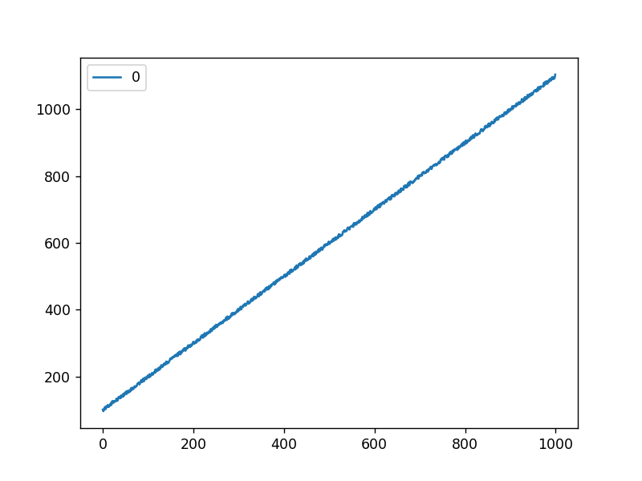

```python
df.plot()
```

# Boucle for : Unpacking

```python
for position, valeur in enumerate(cours_de_bourse): # enumerate renvoie 2 valeurs, stockées dans position et valeur
    print(position, valeur)
    break
```

```
0 101
```

## Calcul d'une variation dans une liste de chiffres

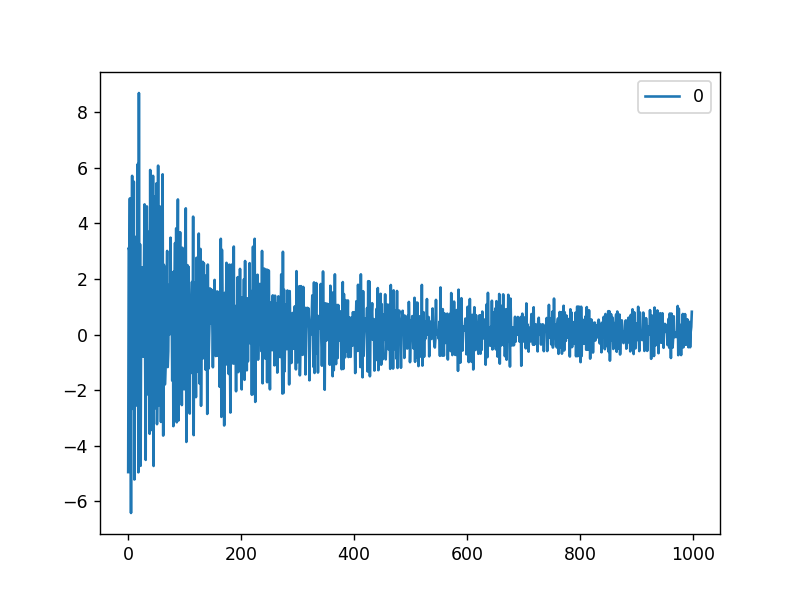

```python
r = []
for position, valeur_today in enumerate(cours_de_bourse): # enumerate renvoie 2 valeurs, stockées dans position et valeur
    if position > 0:
        valeur_veille = cours_de_bourse[position - 1]
        variation     = (valeur_today - valeur_veille )/valeur_veille *100
        r.append(variation)
pd.DataFrame(r).plot()
```

# 6) les dictionnaires : avec des accolades

```python
dico = {
    "clef"    : "valeur",
    "entrée"  : "description",
    "mot"     : "définition"
}
dico
```

```
{'clef': 'valeur', 'entrée': 'description', 'mot': 'définition'}
```

## 6.1) itérer sur un dico

```python
# récupération des clefs
for clef in dico:
    print(clef)
```

```
clef
entrée
mot
```

```python
# aller chercher la valeur pour chaque clef
for clef in dico:
    valeur = dico[clef]
    print(f"clef ={clef:10s}valeur={valeur:10s}")
```

```
clef =clef      valeur=valeur
clef =entrée    valeur=description
clef =mot       valeur=définition
```

```python
# unpacking direct des clefs valeurs via la fonction items
for clef, valeur in dico.items():
    print(f"clef ={clef:10s}valeur={valeur:10s}")
```

```
clef =clef      valeur=valeur
clef =entrée    valeur=description
clef =mot       valeur=définition
```

```python
# aller chercher les valeurs
for valeur in dico.values():
    print(f"valeur = {valeur:10s}")
```

```
valeur = valeur
valeur = description
valeur = définition
```

# 6.2) Import de nltk : Natural Language ToolKit

```python
import nltk
```

```python
nltk.download('gutenberg')
```

```
True
```

```python
textes = nltk.corpus.gutenberg.fileids()
textes
```

```
['austen-emma.txt',
 'austen-persuasion.txt',
 'austen-sense.txt',
 'bible-kjv.txt',
 'blake-poems.txt',
 'bryant-stories.txt',
 'burgess-busterbrown.txt',
 'carroll-alice.txt',
 'chesterton-ball.txt',
 'chesterton-brown.txt',
 'chesterton-thursday.txt',
 'edgeworth-parents.txt',
 'melville-moby_dick.txt',
 'milton-paradise.txt',
 'shakespeare-caesar.txt',
 'shakespeare-hamlet.txt',
 'shakespeare-macbeth.txt',
 'whitman-leaves.txt']
```

```python
nom_fichier = "shakespeare-hamlet.txt"
mots_texte  = nltk.corpus.gutenberg.words(nom_fichier)
```

```python
len(mots_texte)
```

```
37360
```

```python
mots_texte
```

```
['[', 'The', 'Tragedie', 'of', 'Hamlet', 'by', ...]
```

## 6.3) comptage "natif" du nombre d'occurence des mots

```python
for mot in mots_texte:
    if mot not in dico:
        dico[mot] = 0
    dico[mot]+=1
```

## 6.4) utilisation de "defaultdict"

```python
from collections import defaultdict
```

```python
dico = defaultdict(int)
for mot in mots_texte:
    dico[mot]+=1
```

```python
dico
```

```
defaultdict(int,
            {'[': 6,
             'The': 133,
             'Tragedie': 3,
             'of': 576,
             'Hamlet': 99,
             'by': 91,
             'William': 1,
             'Shakespeare': 1,
             '1599': 1,
             ']': 3,
             'Actus': 2,
             'Primus': 1,
             '.': 1886,
             'Scoena': 1,
             'Prima': 1,
             'Enter': 82,
             'Barnardo': 8,
             'and': 606,
             'Francisco': 2,
             'two': 21,
             'Centinels': 1,
             'Who': 24,
             "'": 729,
             's': 122,
             'there': 66,
             '?': 459,
             'Fran': 8,
             'Nay': 25,
             'answer': 8,
             'me': 227,
             ':': 565,
             'Stand': 4,
             '&': 25,
             'vnfold': 3,
             'your': 233,
             'selfe': 66,
             'Bar': 7,
             'Long': 2,
             'liue': 15,
```

[output cut: 947 more lines]

```
             'poore': 19,
             'body': 14,
             'Like': 7,
             'Niobe': 1,
             'teares': 6,
             'beast': 1,
             'wants': 2,
             'discourse': 5,
             'Would': 13,
             'mourn': 1,
             'longer': 4,
             'married': 3,
             'Vnkle': 4,
             'Hercules': 3,
             ...})
```

## 6.5) tri des mots par nombre d'occurence

```python
key= lambda x: dico[x]
```

```python
dico['Would']
```

```
13
```

```python
mots_dans_l_ordre_d_usage = sorted(dico, key= lambda x: dico[x], reverse=True)
n = 5
```

```python
mot_tries_de_plus_de_n_lettres = filter(lambda mot: len(mot)>n, mots_dans_l_ordre_d_usage)
mot_tries_de_plus_de_n_lettres
```

```
<filter at 0x295b71cd040>
```

```python
mot_tries_de_plus_de_n_lettres = list(mot_tries_de_plus_de_n_lettres)
mot_tries_de_plus_de_n_lettres
```

```
['Hamlet',
 'should',
 'speake',
 'Father',
 'thinke',
 'Horatio',
 'Queene',
 'Mother',
 'Heauen',
 'Laertes',
 'againe',
 'Ophelia',
 'cannot',
 'matter',
 'nothing',
 'Exeunt',
 'Denmarke',
 'Polonius',
 'England',
 'Fathers',
 'himselfe',
 'Players',
 'Nature',
 'indeed',
 'meanes',
 'against',
 'Guildensterne',
 'though',
 'follow',
 'better',
 'thoughts',
 'within',
 'beleeue',
 'before',
 'Fortinbras',
 'Gertrude',
 'breath',
 'drinke',
 'speech',
 'madnesse',
```

[output cut: 946 more lines]

```
 'Summons',
 'shrill',
 'sounding',
 'warning',
 'extrauagant',
 'erring',
 'Confine',
 'Obiect',
 'probation',
 'crowing',
 'Sauiours',
 'celebrated',
 'Dawning',
 'singeth',
 ...]
```

```python
_ = mot_tries_de_plus_de_n_lettres
[(mot, dico[mot]) for mot in _]
```

```
[('Hamlet', 99),
 ('should', 52),
 ('speake', 48),
 ('Father', 46),
 ('thinke', 42),
 ('Horatio', 40),
 ('Queene', 39),
 ('Mother', 37),
 ('Heauen', 36),
 ('Laertes', 35),
 ('againe', 34),
 ('Ophelia', 28),
 ('cannot', 26),
 ('matter', 25),
 ('nothing', 23),
 ('Exeunt', 23),
 ('Denmarke', 20),
 ('Polonius', 20),
 ('England', 20),
 ('Fathers', 19),
 ('himselfe', 19),
 ('Players', 19),
 ('Nature', 18),
 ('indeed', 18),
 ('meanes', 18),
 ('against', 17),
 ('Guildensterne', 17),
 ('though', 16),
 ('follow', 16),
 ('better', 15),
 ('thoughts', 15),
 ('within', 15),
 ('beleeue', 14),
 ('before', 13),
 ('Fortinbras', 13),
 ('Gertrude', 13),
 ('breath', 13),
 ('drinke', 13),
 ('speech', 13),
 ('madnesse', 13),
```

[output cut: 946 more lines]

```
 ('Summons', 1),
 ('shrill', 1),
 ('sounding', 1),
 ('warning', 1),
 ('extrauagant', 1),
 ('erring', 1),
 ('Confine', 1),
 ('Obiect', 1),
 ('probation', 1),
 ('crowing', 1),
 ('Sauiours', 1),
 ('celebrated', 1),
 ('Dawning', 1),
 ('singeth', 1),
 ...]
```

# 7) amusons nous

```python
textes
```

```
['austen-emma.txt',
 'austen-persuasion.txt',
 'austen-sense.txt',
 'bible-kjv.txt',
 'blake-poems.txt',
 'bryant-stories.txt',
 'burgess-busterbrown.txt',
 'carroll-alice.txt',
 'chesterton-ball.txt',
 'chesterton-brown.txt',
 'chesterton-thursday.txt',
 'edgeworth-parents.txt',
 'melville-moby_dick.txt',
 'milton-paradise.txt',
 'shakespeare-caesar.txt',
 'shakespeare-hamlet.txt',
 'shakespeare-macbeth.txt',
 'whitman-leaves.txt']
```

```python
'shakespeare-hamlet.txt'.find("-")
```

```
11
```

```python
trouve_auteur = lambda chaine: chaine[:chaine.find("-")]
```

## 7.1) rassembler les auteurs avec leurs oeuvres

```python
dico_auteurs = defaultdict(list)
for nom_texte in textes:
    nom_auteur = trouve_auteur(nom_texte)
    dico_auteurs[nom_auteur].append(nom_texte)
```

### on supprime un texte afin de pouvoir en chercher l'auteur le plus probable

```python
fichier_enleve = dico_auteurs["austen"].pop()
```

```python
fichier_enleve
```

```
'austen-sense.txt'
```

```python
dico_auteurs["austen"]
```

```
['austen-emma.txt', 'austen-persuasion.txt']
```

## 7.2) concaténer les textes pour chaque auteur

```python
get_word = nltk.corpus.gutenberg.words
```

```python
get_word() # fonction pour récupérer les mots pour un texte donné
```

```
['[', 'Emma', 'by', 'Jane', 'Austen', '1816', ']', ...]
```

```python
def get_top_n(liste_de_mots, taille_minimale, n):
    from collections import defaultdict
    dico = defaultdict(int)
    for mot in liste_de_mots:
        dico[mot]+=1

    mots_dans_l_ordre_d_usage      = sorted(dico, key= lambda x: dico[x], reverse=True)

    mot_tries_de_plus_de_n_lettres = filter(lambda mot: len(mot)>taille_minimale,
                                             mots_dans_l_ordre_d_usage)

    mot_tries_de_plus_de_n_lettres = list(mot_tries_de_plus_de_n_lettres)


    r = mot_tries_de_plus_de_n_lettres
    return r[:n]
```

```python
dico_auteurs.items()
```

```
dict_items([('austen', ['austen-emma.txt', 'austen-persuasion.txt']), ('bible', ['bible-kjv.txt']), ('blake', ['blake-poems.txt']), ('bryant', ['bryant-stories.txt']), ('burgess', ['burgess-busterbrown.txt']), ('carroll', ['carroll-alice.txt']), ('chesterton', ['chesterton-ball.txt', 'chesterton-bro…
```

```python
auteur_Vs_texte = {}
for auteur, liste_de_textes in dico_auteurs.items():
    mots = []
    for nom_fichier in liste_de_textes :
        mots.extend(get_word(nom_fichier))

    auteur_Vs_texte[auteur] = get_top_n(mots, 5, 100)
```

```python
database = pd.DataFrame(auteur_Vs_texte)
```

```python
database
```

|  | austen | bible | blake | bryant | burgess | carroll | chesterton | edgeworth | melville | milton | shakespeare | whitman |
| --- | --- | --- | --- | --- | --- | --- | --- | --- | --- | --- | --- | --- |
| 0 | should | Israel | little | little | Buster | little | Turnbull | little | though | Heaven | Caesar | through |
| 1 | little | people | mother | mother | Little | herself | MacIan | father | before | though | Brutus | myself |
| 2 | Harriet | children | father | Jackal | Farmer | thought | little | should | seemed | through | should | before |
| 3 | Weston | before | bright | looked | little | Turtle | seemed | before | Queequeg | things | speake | nothing |
| 4 | herself | against | delight | people | Forest | Hatter | looked | himself | little | without | Hamlet | little |
| ... | ... | ... | ... | ... | ... | ... | ... | ... | ... | ... | ... | ... |
| 95 | whether | wisdom | spreads | strange | bushes | couldn | fellow | reason | ground | whether | Master | darkness |
| 96 | Randalls | Joshua | springs | Prince | nearer | answer | certainly | perhaps | forward | sought | Guildensterne | distant |
| 97 | interest | departed | shining | together | watched | matter | passed | Somers | common | celestial | therefore | voices |
| 98 | therefore | thyself | helpless | across | trying | against | doctor | obliged | stranger | evening | command | certain |
| 99 | agreeable | places | William | rolled | grinned | different | having | stopped | mighty | native | certaine | thoughts |

100 rows × 12 columns

## 7.3) recherchons l'auteur probable d'un texte

```python
fichier_enleve = 'austen-sense.txt'
```

```python
fichier_a_predire = get_top_n(get_word(fichier_enleve), 5, 100)
```

```python
a_predire = pd.DataFrame(fichier_a_predire)
a_predire
```

|  | 0 |
| --- | --- |
| 0 | Elinor |
| 1 | Marianne |
| 2 | sister |
| 3 | Edward |
| 4 | mother |
| ... | ... |
| 95 | interest |
| 96 | thousand |
| 97 | matter |
| 98 | minutes |
| 99 | obliged |

100 rows × 1 columns

## La fonction applymap s'applique élément par élément dans une dataFrame

```python
_ = database.applymap(lambda mot: mot in a_predire.values).sum()
```

```python
_.sort_values(ascending=False)
```

```
austen         62
edgeworth      43
chesterton     42
melville       38
carroll        32
whitman        28
bryant         26
burgess        21
milton         20
shakespeare    18
bible          18
blake          10
dtype: int64
```

## En regardant l'occurence des mots, on ordonne les auteurs dans l'ordre du plus probable : de Austen (plus probable, et effectivement le bon auteur) à edgeworth puis les autres....

# 8) classes

```python
class oeuvre():
    def __init__(self, auteur, titre ):
        """
        Méthode d'instanciation
        """
        self.auteur = auteur
        self.titre  = titre
    def __str__(self):
        """
        Méthode d'affichage
        """
        return f"{self.auteur} : {self.titre}"
```

```python
guerre_et_paix = oeuvre("Tolstoi", "guerre et paix")
print(guerre_et_paix)
```

```
Tolstoi : guerre et paix
```

## on peut rajouter des attributs à un objet, même s'il n'est pas dans la définition de la classe

```python
guerre_et_paix.nouvel_attribut = "coucou"
```

```python
guerre_et_paix.nouvel_attribut
```

```
'coucou'
```

# 8.1) héritage de classes

```python
class sculpture(oeuvre): # sculpture hérite de la classe oeuvre
    def __init__(self, auteur, titre, matériel):
        self.matériel = matériel
        super(sculpture, self).__init__(auteur, titre) # Appel de la fonction d'initialisation de la classe mère

    def __str__(self): # Surcharge de la méthode print
        return super(sculpture, self).__str__() + \
    " sculpture en  "+ self.matériel
```

```python
class livre(oeuvre): # livre hérite de la classe oeuvre

    def __init__(self, auteur, titre, nb_de_pages):
        self.nb_de_pages = nb_de_pages
        super(livre, self).__init__(auteur, titre) # Appel de la fonction d'initialisation de la classe mère

    def __str__(self): # Surcharge de la méthode print
        return f"""
        {self.titre} de {self.auteur} avec {self.nb_de_pages} pages
        """
```

```python
le_penseur = sculpture("Rodin", "le penseur", "bronze")
print(le_penseur)
```

```
Rodin : le penseur sculpture en  bronze
```

```python
guerre_et_paix = livre("Tolstoi", "guerre et paix", 1000)
```

```python
print(guerre_et_paix)
```

```
        guerre et paix de Tolstoi avec 1000 pages
```